# 第5章: 発見 (5.2. ネットワークデータ)

今井耕介 著 『社会科学のためのデータ分析入門 (QSS)』

2026-03-09

# 5.2 ネットワークデータ

# 社会ネットワーク分析

- **ノード** (Nodes/Vertices): 個人や組織などの実体。
- **エッジ** (Edges/Links): ノード間の関係（友人、取引、引用など）。
- **目標**: ネットワークの構造を理解し、中心的な役割を果たすノードを特定する。

# 5.2.1 ルネサンス期フィレンツェの婚姻ネットワーク

# 隣接行列 (Adjacency Matrix)

- ネットワークを行列形式で表現する。
- 行と列が各家族を表し、関係があれば 1、なければ 0。

```r
# データの読み込み（FAMILY列を行名にする）
florence <- read.csv("florentine.csv", row.names = "FAMILY")
# 最初の5家族分を表示
as.matrix(florence)[1:5, 1:5]
```

```
##           ACCIAIUOL ALBIZZI BARBADORI BISCHERI CASTELLAN
## ACCIAIUOL         0       0         0        0         0
## ALBIZZI           0       0         0        0         0
## BARBADORI         0       0         0        0         1
## BISCHERI          0       0         0        0         0
## CASTELLAN         0       0         1        0         0
```

# 5.2.2 グラフと中心性指標

# igraph によるネットワークの作成

- **無向グラフ**: 関係に方向がない場合（婚姻など）。

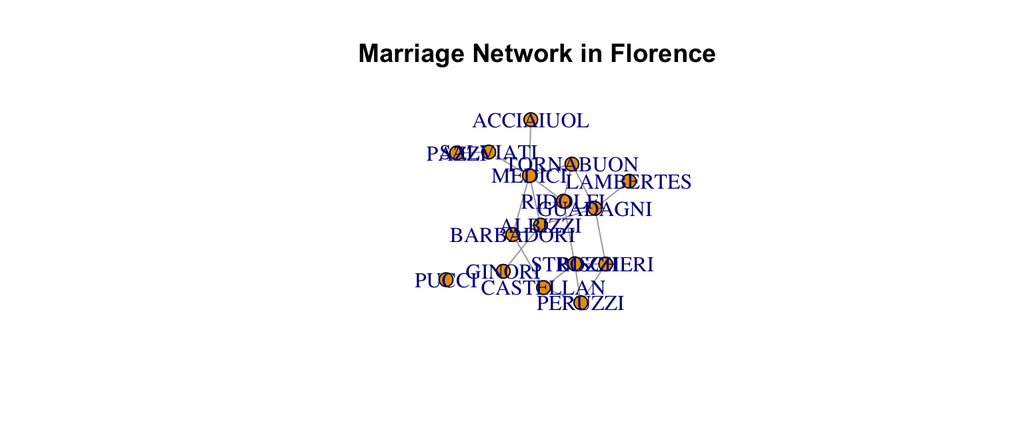

```r
library(igraph)
# 隣接行列からグラフを作成
g <- graph_from_adjacency_matrix(as.matrix(florence), mode = "undirected")
# プロット
plot(g, main = "Marriage Network in Florence")
```

# 中心性指標 (1): 次数中心性

- **次数中心性 (Degree)**: 直接つながっているエッジの数。

```r
# つながりが多い家族トップ3
sort(degree(g), decreasing = TRUE)[1:3]
```

```
##   MEDICI GUADAGNI  STROZZI
##        6        4        4
```

# 中心性指標 (2): 近接中心性

- **近接中心性 (Closeness)**: 他の全てのノードへの距離の短さ。

```r
# 他の家族へのアクセスが容易な家族
sort(closeness(g), decreasing = TRUE)[1:3]
```

```
##     MEDICI    RIDOLFI    ALBIZZI
## 0.04000000 0.03571429 0.03448276
```

# 中心性指標 (3): 間中心性

- **間中心性 (Betweenness)**: ノード間の最短経路上の通過回数。
- 「仲介者」としての重要度を測る。

```r
# ネットワークのハブとなる家族
sort(betweenness(g), decreasing = TRUE)[1:3]
```

```
##   MEDICI GUADAGNI  ALBIZZI
## 47.50000 23.16667 19.33333
```

# 5.2.3 Twitterのフォローネットワーク

# 有向グラフ (Directed Graph)

- **有向グラフ**: フォロー関係のように、向きがあるエッジ。
- 入次数 (In-degree) と出次数 (Out-degree) を区別する。

```r
twitter <- read.csv("twitter-following.csv", stringsAsFactors = FALSE)
senator <- read.csv("twitter-senator.csv", stringsAsFactors = FALSE)
# 隣接行列の初期化と作成（コード省略）
n <- nrow(senator); twitter.adj <- matrix(0, nrow = n, ncol = n)
colnames(twitter.adj) <- rownames(twitter.adj) <- senator$screen_name
for (i in 1:nrow(twitter)) {
    twitter.adj[twitter$following[i], twitter$followed[i]] <- 1
}
g.tw <- graph_from_adjacency_matrix(twitter.adj, mode = "directed")
```

# 5.2.4 PageRank アルゴリズム

# PageRank とは

- 重要なノードからフォローされているノードをより高く評価する指標。
- Googleの検索エンジンでも使われる基本的なアルゴリズム。

```r
# PageRankの計算
senator$pagerank <- page_rank(g.tw)$vector
# PageRankが高い上院議員トップ3
senator$name[order(senator$pagerank, decreasing = TRUE)][1:3]
```

```
## [1] "John McCain"     "John Cornyn"     "Martin Heinrich"
```

# ネットワークの視覚化（PageRank）

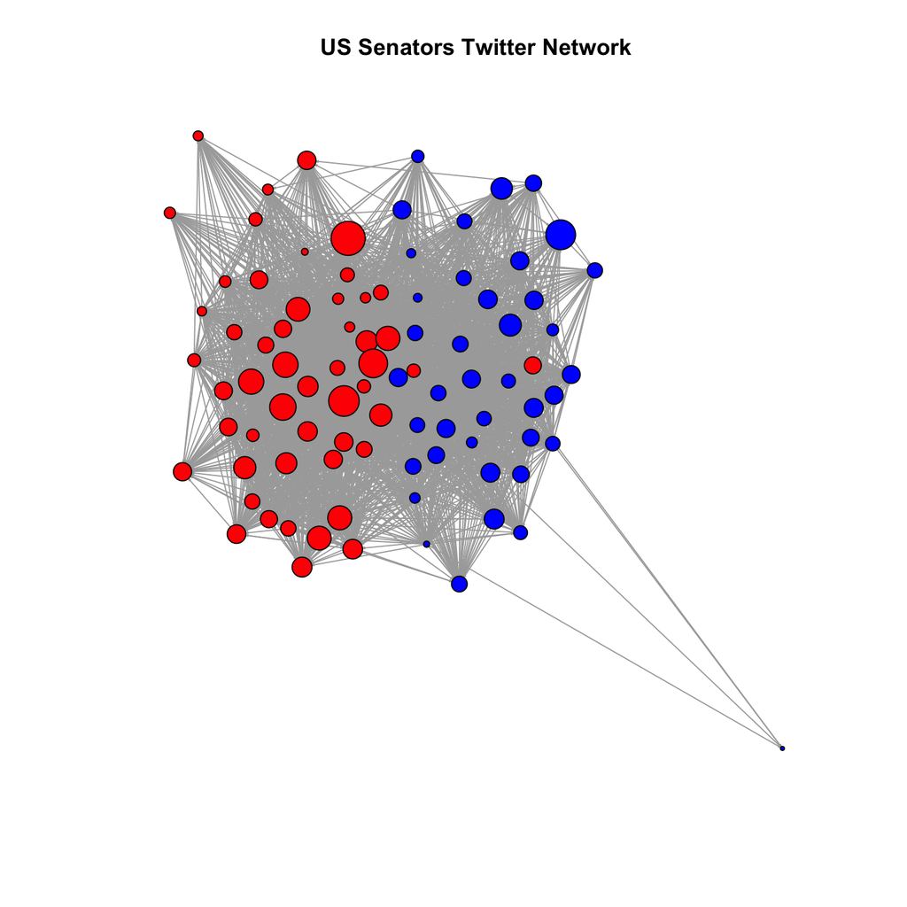

```r
# 政党別の色分け (D=Blue, R=Red)
col <- ifelse(senator$party == "D", "blue", "red")
# PageRankに基づくサイズ調整
plot(g.tw, vertex.size = senator$pagerank * 500,
     vertex.color = col, vertex.label = NA,
     edge.arrow.size = 0.1, main = "US Senators Twitter Network")
```

# 5.2.5 まとめ

# まとめ

- **ネットワークデータ**: 要素間の「つながり」を隣接行列やグラフで表現する。
- **中心性指標**:
  - **次数**: つながりの多さ。
  - **近接**: 全体へのアクセスの良さ。
  - **間**: 仲介役としての重要性。
- **PageRank**: つながりの「質」を考慮した重要度。
- **視覚化**: グラフの描画によって直感的な理解を促す。